# Problem: Knots vs Links

In topology one draws knots/links in the 3-dimensional euclidean space by projecting them into a 2-dimensional plane and marking crossings accordingly. A knot is a single piece of string, a link is multiple. (see image for explanation) For people it's very easy to tell apart knots from links. But algorithmically it turns out to be painful.

[figure not shown]

```python
from skimage.morphology import skeletonize
from skimage import data
import numpy as np
from PIL import Image
import matplotlib.pyplot as plt
from skimage.util import invert
import cv2 as cv
```

Loading image. Originally image has values such as [30,100,255]. We convert this to 0,1 as in white/black respectively.

```python
im = np.asarray(Image.open('image1.png'))
imN=np.zeros((im.shape[:2]))
for i in range(im.shape[0]):
  for j in range(im.shape[1]):
    if (np.sum(im[i][j])<1000):
      imN[i][j]=False
    else:
      imN[i][j]=True
```

scikit-image has a built in function that skeletonizes the image. This function is very good for us, since the skeleton is very regular - for example there are no L blocks.

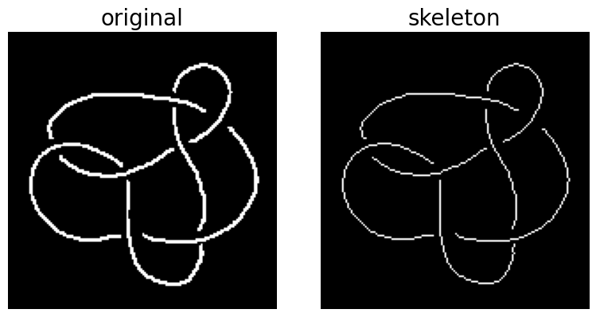

```python
image = 1-imN

# perform skeletonization
skeleton = skeletonize(image)

fig, axes = plt.subplots(nrows=1, ncols=2, figsize=(8, 4), sharex=True, sharey=True)

ax = axes.ravel()

ax[0].imshow(image, cmap=plt.cm.gray)
ax[0].axis('off')
ax[0].set_title('original', fontsize=20)

ax[1].imshow(skeleton, cmap=plt.cm.gray)
ax[1].axis('off')
ax[1].set_title('skeleton', fontsize=20)

fig.tight_layout()
plt.show()
```

The regularity of the skeleton allows us to easily find the vertices - they are the points such that the 3x3 square around them has exactly two points. with L blocks this wouldn't be possible.

```python
A=[]
for x in range(1,skeleton.shape[0]-1):
  for y in range(1,skeleton.shape[1]-1):
    if skeleton[x,y]==True:
      s=skeleton[x-1:x+2,y-1:y+2]
      if np.sum(s)==2:
        A.append([x,y])
A=np.array(A)
```

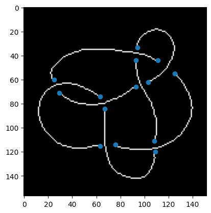

```python
plt.imshow(skeleton,  cmap=plt.cm.gray)
plt.scatter(A[:, 1],A[:,0])
```

Now we need to solve a problem: we want to travel around the graph. For that we need two functions.

- to jump over the crossing point, find the nearest edge point
- in a component, find the other edge point

Here we find the closest points to each edge point

Note that this is just a permutation and a pairing

```python
B=np.zeros((A.shape))
def closestPt(pt,Set):
  index=0
  minimal=np.inf
  for i in range(0,len(Set)):
    p=(Set[i][0]-pt[0])**2+(Set[i][1]-pt[1])**2
    if p<minimal and p>0:
      index=i
      minimal=p
  return Set[index]

for i in range(len(A)):
  B[i]=closestPt(A[i],A)
```

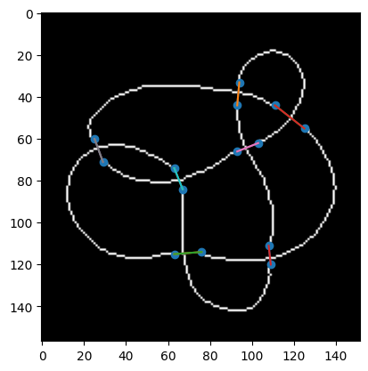

```python
plt.imshow(skeleton,  cmap=plt.cm.gray)
plt.scatter(A[:,1],A[:,0])
for i in range(len(A)):
  plt.plot([A[i,1],B[i,1]],[A[i,0],B[i,0]])
```

The following is super messy, but it works. This part just finds the other end by traversing the line.

```python
A=np.ndarray.tolist(A)
def notIn(a,Set):
  for i in range(len(Set)):
    if Set[i]==a:
      return False

  return True
def otherOneInSquare(current, notThese):
  for a in range(-1,2):
    for b in range(-1,2):
      #print(skeleton[current[0]+a][current[1]+b])
      if (skeleton[current[0]+a][current[1]+b]==True) and (notIn([current[0]+a,current[1]+b], notThese)):
        return [current[0]+a,current[1]+b]

def findOtherEnd(start):
  lastPt=start
  currentPt = otherOneInSquare(lastPt, [lastPt])

  while (notIn(currentPt,list(A))):
    temp=currentPt
    currentPt = otherOneInSquare(currentPt, [currentPt,lastPt])
    lastPt=temp
  return currentPt
```

Visual check

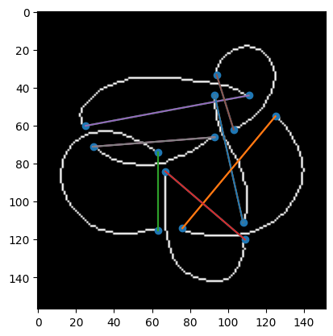

```python
C=[]
for i in A:
  C.append(findOtherEnd(i))
C=np.array(C)
plt.imshow(skeleton,  cmap=plt.cm.gray)
A=np.array(A)
plt.scatter(A[:,1],A[:,0])
for i in range(len(A)):
  plt.plot([A[i,1],C[i,1]],[A[i,0],C[i,0]])
```

Now we can algorithmically check if this is a knot: start at any point. Go to the other end of the edge, then jump and repeat. If we get to the starting point without going to every point, then this is a link. else a knot.

```python
A=A=np.ndarray.tolist(A)
def findIndex(a,A):
  for i in range(len(A)):
    if A[i]==a:
      return i
p=A[0]

isKnot=1
for i in range(int(len(A)/2)):
  p=np.ndarray.tolist(np.array(p))
  p=[int(p[0]),int(p[1])]
  q=list(findOtherEnd(p))
  p=B[findIndex(q,A)]
  if list(p)==A[0] and i!=len(A)//2-1:
    isKnot=0
print(isKnot)
```

```
1
```